# Baseline_models_quarterly

## Overview

- Country: United States, France, Germany, Japan, United Kingdom, Italy, Canada
- Time period: 1950-2018, 69 years
- Target variable: `ngdp_rpch` for annual data, `ngdp_r_sa_pcha` and `ngdp_r_sa_pchy` (respectively) for quarterly data
- Train-test split: 1950-2009 (train, ≤60 years, depends on data availability), 2010-2018 (test, 9 years)  
  *Need further discussion. Here I divide the dataset by 2009/2010 just as the working paper did. Now for the MA model family we do not need to do such split.*

## 1. Get GDP data for all 7 countries

Reference: [IPython Magics for BigQuery](https://googleapis.dev/python/bigquery/latest/magics.html)  
We can also run [parameterized queries](https://cloud.google.com/bigquery/docs/parameterized-queries#bigquery_query_params_arrays-python), but it's not the optimal choice in our case.

```python
import pandas as pd
import numpy as np
import matplotlib.pyplot as plt
plt.style.use('ggplot')
```

### 1.1 Table for `ngdp_r_sa_pcha`: **gdp_quarterly_q**

```python
%%bigquery gdp_quarterly_q
SELECT country, time, ngdp_r_sa_pcha AS gdp
FROM `deep-nexus.temp_for_imf_data.WEO_G7_Quarterly`
ORDER BY time
```

```python
gdp_quarterly_q.year = (gdp_quarterly_q.time+40)//4 + 1950
gdp_quarterly_q.quarter = (gdp_quarterly_q.time+40)%4 + 1
gdp_quarterly_q.time = gdp_quarterly_q.year.astype('str') + 'Q' + gdp_quarterly_q.quarter.astype('str')
```

```python
gdp_quarterly_q = gdp_quarterly_q.pivot(index='time', columns='country', values='gdp')
gdp_quarterly_q = gdp_quarterly_q.dropna(how='all')
gdp_quarterly_q.head(10)
```

| country time | Canada | France | Germany | Italy | Japan | United Kingdom | United States |
| --- | --- | --- | --- | --- | --- | --- | --- |
| 1955Q2 | NaN | NaN | NaN | NaN | NaN | 0.905996 | NaN |
| 1955Q3 | NaN | NaN | NaN | NaN | NaN | 5.501536 | NaN |
| 1955Q4 | NaN | NaN | NaN | NaN | NaN | -2.082750 | NaN |
| 1956Q1 | NaN | NaN | NaN | NaN | NaN | 1.757439 | NaN |
| 1956Q2 | NaN | NaN | NaN | NaN | NaN | 0.899588 | NaN |
| 1956Q3 | NaN | NaN | NaN | NaN | NaN | 0.519995 | NaN |
| 1956Q4 | NaN | NaN | NaN | NaN | NaN | 1.081904 | NaN |
| 1957Q1 | NaN | NaN | NaN | NaN | NaN | 5.914982 | NaN |
| 1957Q2 | NaN | NaN | NaN | NaN | NaN | 1.327352 | NaN |
| 1957Q3 | NaN | NaN | NaN | NaN | NaN | -2.095001 | NaN |

### 1.2 Table for `ngdp_r_sa_pchy`: **gdp_quarterly_y**

```python
%%bigquery gdp_quarterly_y
SELECT country, time, ngdp_r_sa_pchy AS gdp
FROM `deep-nexus.temp_for_imf_data.WEO_G7_Quarterly`
ORDER BY time
```

```python
gdp_quarterly_y.year = (gdp_quarterly_y.time+40)//4 + 1950
gdp_quarterly_y.quarter = (gdp_quarterly_y.time+40)%4 + 1
gdp_quarterly_y.time = gdp_quarterly_y.year.astype('str') + 'Q' + gdp_quarterly_y.quarter.astype('str')
```

```python
gdp_quarterly_y = gdp_quarterly_y.pivot(index='time', columns='country', values='gdp')
gdp_quarterly_y = gdp_quarterly_y.dropna(how='all')
gdp_quarterly_y.head(10)
```

| country time | Canada | France | Germany | Italy | Japan | United Kingdom | United States |
| --- | --- | --- | --- | --- | --- | --- | --- |
| 1956Q1 | NaN | NaN | NaN | NaN | NaN | 1.484633 | NaN |
| 1956Q2 | NaN | NaN | NaN | NaN | NaN | 1.483021 | NaN |
| 1956Q3 | NaN | NaN | NaN | NaN | NaN | 0.263257 | NaN |
| 1956Q4 | NaN | NaN | NaN | NaN | NaN | 1.063738 | NaN |
| 1957Q1 | NaN | NaN | NaN | NaN | NaN | 2.080589 | NaN |
| 1957Q2 | NaN | NaN | NaN | NaN | NaN | 2.188610 | NaN |
| 1957Q3 | NaN | NaN | NaN | NaN | NaN | 1.517425 | NaN |
| 1957Q4 | NaN | NaN | NaN | NaN | NaN | 1.353511 | NaN |
| 1958Q1 | NaN | NaN | NaN | NaN | NaN | 0.754262 | NaN |
| 1958Q2 | NaN | NaN | NaN | NaN | NaN | -1.236259 | NaN |

Note the data is only available since 1955Q2 and 1956Q1 respectively. Check data length:

```python
len_q = len(gdp_quarterly_q)
len_y = len(gdp_quarterly_y)
len_q, len_y
```

```
(255, 252)
```

Check number of data points for each country:

```python
len_dict_q = {country:gdp_quarterly_q[country].count() for country in gdp_quarterly_q.columns}
len_dict_y = {country:gdp_quarterly_y[country].count() for country in gdp_quarterly_y.columns}
len_dict_q, len_dict_y
```

```
({'Canada': 151,
  'France': 195,
  'Germany': 111,
  'Italy': 151,
  'Japan': 155,
  'United Kingdom': 255,
  'United States': 159},
 {'Canada': 148,
  'France': 192,
  'Germany': 108,
  'Italy': 148,
  'Japan': 152,
  'United Kingdom': 252,
  'United States': 156})
```

## 2. MA

$$ \hat{\mu}_{t+\Delta} = \frac{1}{n} \sum_{i=1}^{n} X_{t-(i-1)\Delta} $$$$ \hat{\sigma}^2_{t+\Delta} = \frac{1}{n-1} \sum_{i=1}^{n} (X_{t-(i-1)\Delta}-\hat{\mu}_{t+\Delta})^2 $$

> *I choose window size as 10. We could discuss the param later.*

```python
def moving_average_forecast(df, window_size):
    mov = np.cumsum(df).values
    mov_avg = (mov[window_size:] - mov[:-window_size]) / window_size
    df_mov_avg = pd.DataFrame(data=mov_avg[:-1], index=df.index[window_size+1:], columns=df.columns)
    return df_mov_avg
```

### 2.1 gdp_quarterly_q

```python
window_size = 10
forecast_ma_q = moving_average_forecast(gdp_quarterly_q, window_size)
forecast_ma_q.head()
```

| country time | Canada | France | Germany | Italy | Japan | United Kingdom | United States |
| --- | --- | --- | --- | --- | --- | --- | --- |
| 1958Q1 | NaN | NaN | NaN | NaN | NaN | 1.325569 | NaN |
| 1958Q2 | NaN | NaN | NaN | NaN | NaN | 1.118638 | NaN |
| 1958Q3 | NaN | NaN | NaN | NaN | NaN | 0.682330 | NaN |
| 1958Q4 | NaN | NaN | NaN | NaN | NaN | 1.182784 | NaN |
| 1959Q1 | NaN | NaN | NaN | NaN | NaN | 1.197069 | NaN |

### Plot the forecast versus real data

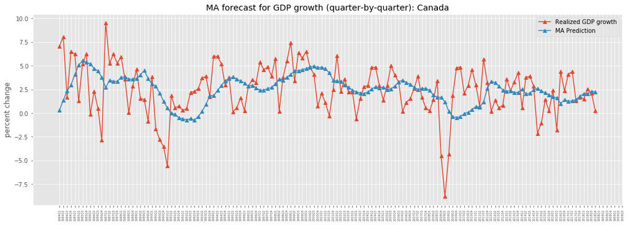

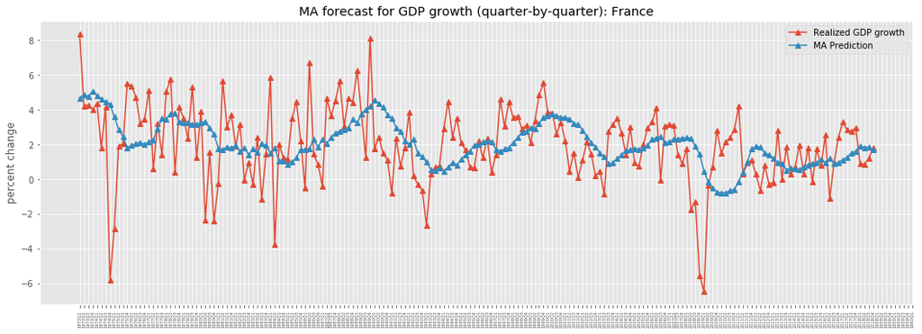

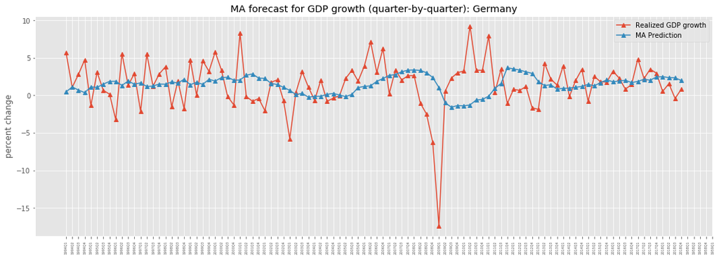

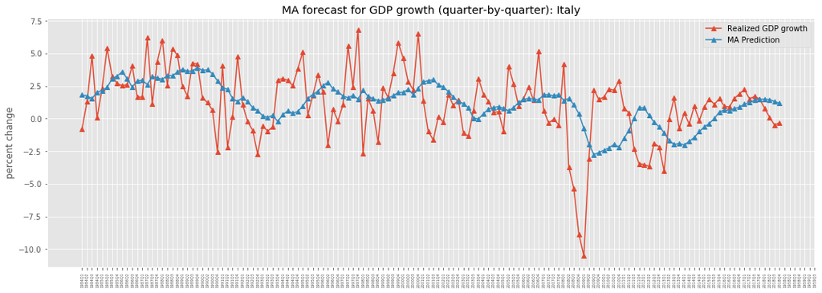

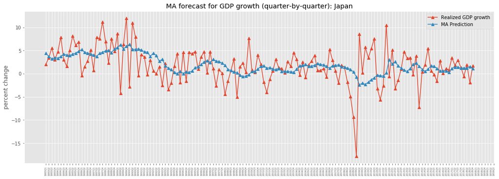

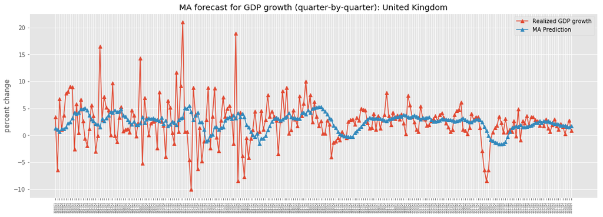

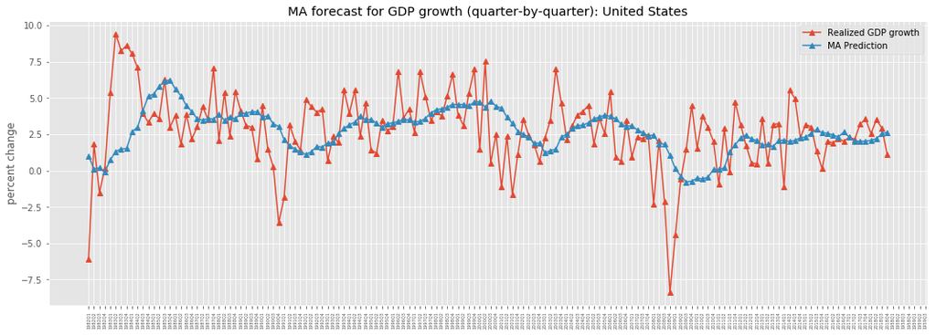

```python
for country in gdp_quarterly_q.columns:
    plt.figure(figsize=(18, 6))
    plt.plot(gdp_quarterly_q[(window_size+len_q-len_dict_q[country])+1:][country], marker='^', label='Realized GDP growth')
    plt.plot(forecast_ma_q[country], marker='^', label='MA Prediction')
    plt.title('MA forecast for GDP growth (quarter-by-quarter): ' + country)
    plt.xticks(rotation=90, fontsize=5)
    plt.ylabel('percent change')
    plt.legend()
    plt.show()
```

> MA is not a good indicator for growth data.  
> Usually we use MA for price process or return volatility process, but not for return/growth process.

### Error

```python
df_error_ma_q = gdp_quarterly_q[window_size+1:] - forecast_ma_q
df_error_ma_q.head()
```

| country time | Canada | France | Germany | Italy | Japan | United Kingdom | United States |
| --- | --- | --- | --- | --- | --- | --- | --- |
| 1958Q1 | NaN | NaN | NaN | NaN | NaN | 2.106663 | NaN |
| 1958Q2 | NaN | NaN | NaN | NaN | NaN | -7.564475 | NaN |
| 1958Q3 | NaN | NaN | NaN | NaN | NaN | 6.079648 | NaN |
| 1958Q4 | NaN | NaN | NaN | NaN | NaN | -0.140343 | NaN |
| 1959Q1 | NaN | NaN | NaN | NaN | NaN | 2.518396 | NaN |

```python
mae_ma_q = abs(df_error_ma_q).mean()
mae_ma_q
```

```
country
Canada            2.257311
France            1.740559
Germany           2.643361
Italy             2.102155
Japan             2.967128
United Kingdom    2.871621
United States     1.939902
dtype: float64
```

```python
rmse_ma_q = np.sqrt((df_error_ma_q**2).mean())
rmse_ma_q
```

```
country
Canada            2.870082
France            2.298152
Germany           3.661650
Italy             2.708143
Japan             3.961315
United Kingdom    4.135178
United States     2.624528
dtype: float64
```

> *RMSE is much larger than the one used as benchmark in the working paper, which takes an RMSE of 0.72 for United States and 0.63 for United Kingdom. Personally MA is not a good model for growth data. We should use another model as benchmark.*

### 2.2 gdp_quarterly_y

```python
forecast_ma_y = moving_average_forecast(gdp_quarterly_y, window_size)
forecast_ma_y.head()
```

| country time | Canada | France | Germany | Italy | Japan | United Kingdom | United States |
| --- | --- | --- | --- | --- | --- | --- | --- |
| 1958Q4 | NaN | NaN | NaN | NaN | NaN | 1.039355 | NaN |
| 1959Q1 | NaN | NaN | NaN | NaN | NaN | 0.998928 | NaN |
| 1959Q2 | NaN | NaN | NaN | NaN | NaN | 1.087390 | NaN |
| 1959Q3 | NaN | NaN | NaN | NaN | NaN | 1.461242 | NaN |
| 1959Q4 | NaN | NaN | NaN | NaN | NaN | 1.767386 | NaN |

### Plot the forecast versus real data

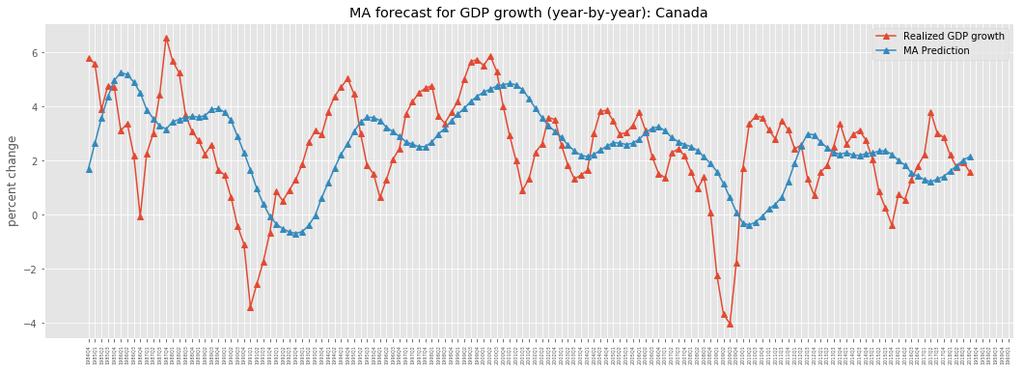

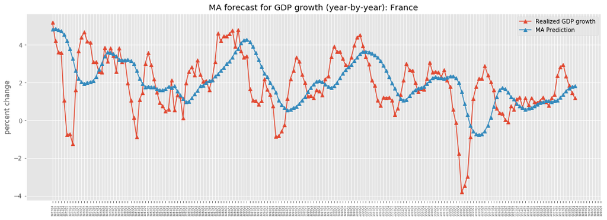

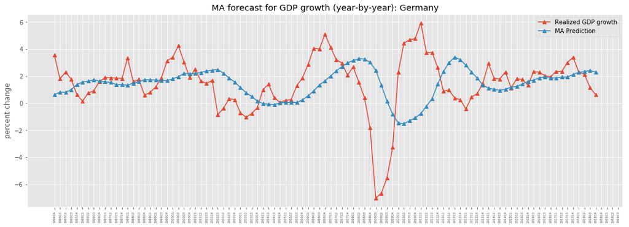

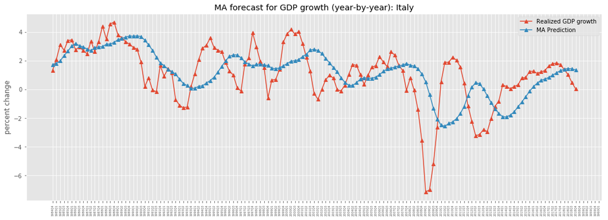

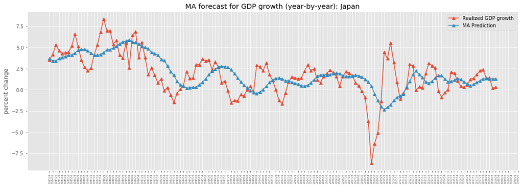

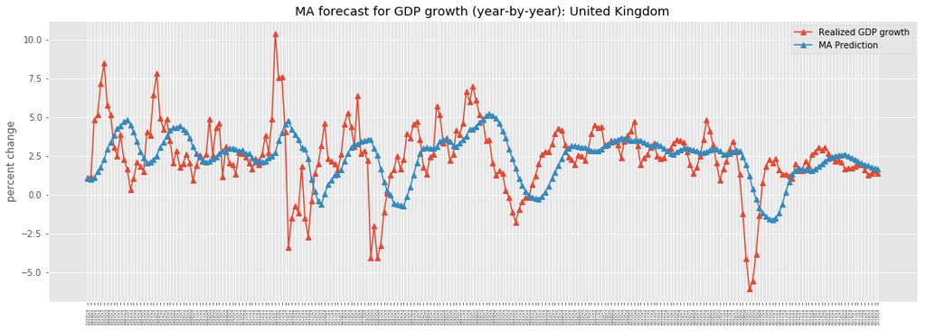

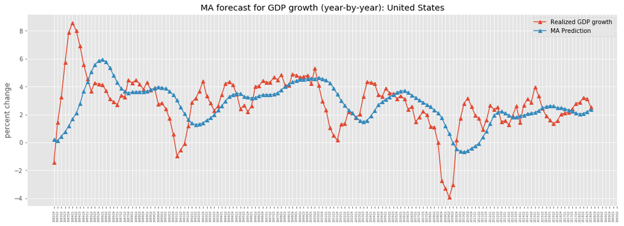

```python
for country in gdp_quarterly_y.columns:
    plt.figure(figsize=(18, 6))
    plt.plot(gdp_quarterly_y[(window_size+len_y-len_dict_y[country])+1:][country], marker='^', label='Realized GDP growth')
    plt.plot(forecast_ma_y[country], marker='^', label='MA Prediction')
    plt.title('MA forecast for GDP growth (year-by-year): ' + country)
    plt.xticks(rotation=90, fontsize=5)
    plt.ylabel('percent change')
    plt.legend()
    plt.show()
```

> *Looks a little better than the quarter-by-quarter indicator.*

### Error

```python
df_error_ma_y = gdp_quarterly_y[window_size+1:] - forecast_ma_y
df_error_ma_y.head()
```

| country time | Canada | France | Germany | Italy | Japan | United Kingdom | United States |
| --- | --- | --- | --- | --- | --- | --- | --- |
| 1958Q4 | NaN | NaN | NaN | NaN | NaN | 0.039395 | NaN |
| 1959Q1 | NaN | NaN | NaN | NaN | NaN | 0.148948 | NaN |
| 1959Q2 | NaN | NaN | NaN | NaN | NaN | 3.714870 | NaN |
| 1959Q3 | NaN | NaN | NaN | NaN | NaN | 3.680788 | NaN |
| 1959Q4 | NaN | NaN | NaN | NaN | NaN | 5.392899 | NaN |

```python
mae_ma_y = abs(df_error_ma_y).mean()
mae_ma_y
```

```
country
Canada            1.592833
France            1.184744
Germany           1.688493
Italy             1.447747
Japan             1.630188
United Kingdom    1.690009
United States     1.376016
dtype: float64
```

```python
rmse_ma_y = np.sqrt((df_error_ma_y**2).mean())
rmse_ma_y
```

```
country
Canada            1.965565
France            1.574456
Germany           2.464158
Italy             1.942959
Japan             2.202636
United Kingdom    2.342988
United States     1.898043
dtype: float64
```

> *RMSE is significantly smaller than the quarter-by-quarter indicator, but still not good enough.*

### 2.3 Error comparison

```python
mae_ma = pd.concat([mae_ma_q, mae_ma_y], axis=1)
mae_ma.columns = ['quarter-by-quarter', 'year-by-year']
mae_ma
```

| country | quarter-by-quarter | year-by-year |
| --- | --- | --- |
| Canada | 2.257311 | 1.592833 |
| France | 1.740559 | 1.184744 |
| Germany | 2.643361 | 1.688493 |
| Italy | 2.102155 | 1.447747 |
| Japan | 2.967128 | 1.630188 |
| United Kingdom | 2.871621 | 1.690009 |
| United States | 1.939902 | 1.376016 |

```python
rmse_ma = pd.concat([rmse_ma_q, rmse_ma_y], axis=1)
rmse_ma.columns = ['quarter-by-quarter', 'year-by-year']
rmse_ma
```

| country | quarter-by-quarter | year-by-year |
| --- | --- | --- |
| Canada | 2.870082 | 1.965565 |
| France | 2.298152 | 1.574456 |
| Germany | 3.661650 | 2.464158 |
| Italy | 2.708143 | 1.942959 |
| Japan | 3.961315 | 2.202636 |
| United Kingdom | 4.135178 | 2.342988 |
| United States | 2.624528 | 1.898043 |

> *Guess: The year-by-year growth itself contains somewhat "moving average" and looks much smoother than the quarter-by-quarter growth.*

## 3. EWMA

Recursive formula:

$$ \hat{\mu}_{t+\Delta} = \lambda_{1} \mu_{t} + (1-\lambda_{1}) X_{t} $$$$ \hat{\sigma}^2_{t+\Delta} = \lambda_{2} \sigma^2_{t} + (1-\lambda_{2}) (X_{t}-\mu_{t})^2 $$

Typical value (aka industry convention) of 𝜆 is 0.97 or 0.94.

Full expression:

$$ \hat{\mu}_{t+\Delta} = \alpha_{0} X_{0} + \sum_{i=1}^{n} \alpha_{i} X_{t-(i-1)\Delta} $$$$ \hat{\sigma}^2_{t+\Delta} = \alpha_{0} V_{0} + \sum_{i=1}^{n} \alpha_{i} X^2_{t-(i-1)\Delta} $$

where $\alpha_{0}=\lambda^{n}$, $\alpha_{i}=(1-\lambda) \lambda^{i-1}$, $i=1,2,...,n$.

> *Potential problem with EWMA: The initial value $X*{0}$ (or $V*{0}$) is actually the long term mean. It's hard to tell if GDP growth has a long term mean. If not, then it doesn't make sense to take any value as $X*{0}$. The industry convention is to use the average of first $M$ values in the time series as the initial value, where $M$ is often larger than 100._

### 3.1 gdp_quarterly_q

**Method1. Use a user-defined function to calculate EWMA, similar to MA.**  
Take the average of first 50 values as $X_{0}$ and then use the recursive formula to make EWMA predictions. The reason for take the initial window size $M$=50 is because we have limited data in this case. $M$ could be changed.

```python
def weighted_moving_average_forecast(df, window_size, theta):
    def ewma(series):
        start_loc = series.index.get_loc(series.first_valid_index())
        end_loc = start_loc + window_size
        mov = np.array(series)
        miu = mov[start_loc:end_loc].mean()
        mov[start_loc:end_loc] = np.nan
        for loc in range(0, len(mov[end_loc:])):
            miu = theta*miu + (1-theta)*mov[end_loc+loc]
            mov[end_loc+loc] = miu
        series_mov = pd.Series(data=mov, index=series.index)
        return series_mov
    return df.apply(ewma).dropna(how='all')
```

```python
window_size = 50
theta1, theta2 = 0.97, 0.94
```

```python
forecast_ewma97_q = weighted_moving_average_forecast(gdp_quarterly_q, window_size, theta1)
forecast_ewma94_q = weighted_moving_average_forecast(gdp_quarterly_q, window_size, theta2)
```

```python
forecast_ewma97_q.head()
```

| country time | Canada | France | Germany | Italy | Japan | United Kingdom | United States |
| --- | --- | --- | --- | --- | --- | --- | --- |
| 1967Q4 | NaN | NaN | NaN | NaN | NaN | 2.779713 | NaN |
| 1968Q1 | NaN | NaN | NaN | NaN | NaN | 3.125508 | NaN |
| 1968Q2 | NaN | NaN | NaN | NaN | NaN | 2.874301 | NaN |
| 1968Q3 | NaN | NaN | NaN | NaN | NaN | 2.996640 | NaN |
| 1968Q4 | NaN | NaN | NaN | NaN | NaN | 3.004607 | NaN |

```python
forecast_ewma94_q.head()
```

| country time | Canada | France | Germany | Italy | Japan | United Kingdom | United States |
| --- | --- | --- | --- | --- | --- | --- | --- |
| 1967Q4 | NaN | NaN | NaN | NaN | NaN | 2.763132 | NaN |
| 1968Q1 | NaN | NaN | NaN | NaN | NaN | 3.455718 | NaN |
| 1968Q2 | NaN | NaN | NaN | NaN | NaN | 2.933492 | NaN |
| 1968Q3 | NaN | NaN | NaN | NaN | NaN | 3.174618 | NaN |
| 1968Q4 | NaN | NaN | NaN | NaN | NaN | 3.179873 | NaN |

**Method2. Use `df.ewm()`**

Note: `df.ewm()` automatically takes the first non-null value as the initial value $X_{0}$. If we don't care much about the validity of a long term mean (as it may not exist in essence), then it doesn't hurt much to use it. Note that the results are slightly different from the ones generated by the `weighted_moving_average_forecast` function.

**EWMA97:**

```python
gdp_quarterly_q.ewm(min_periods=window_size, alpha=1-theta1).mean().dropna(how='all')[:-1].set_index(forecast_ewma97_q.index).head()
```

| country time | Canada | France | Germany | Italy | Japan | United Kingdom | United States |
| --- | --- | --- | --- | --- | --- | --- | --- |
| 1967Q4 | NaN | NaN | NaN | NaN | NaN | 2.860244 | NaN |
| 1968Q1 | NaN | NaN | NaN | NaN | NaN | 2.836782 | NaN |
| 1968Q2 | NaN | NaN | NaN | NaN | NaN | 3.269688 | NaN |
| 1968Q3 | NaN | NaN | NaN | NaN | NaN | 2.950663 | NaN |
| 1968Q4 | NaN | NaN | NaN | NaN | NaN | 3.099430 | NaN |

**EWMA94:**

```python
gdp_quarterly_q.ewm(min_periods=window_size, alpha=1-theta2).mean().dropna(how='all')[:-1].set_index(forecast_ewma94_q.index).head()
```

| country time | Canada | France | Germany | Italy | Japan | United Kingdom | United States |
| --- | --- | --- | --- | --- | --- | --- | --- |
| 1967Q4 | NaN | NaN | NaN | NaN | NaN | 2.791613 | NaN |
| 1968Q1 | NaN | NaN | NaN | NaN | NaN | 2.757269 | NaN |
| 1968Q2 | NaN | NaN | NaN | NaN | NaN | 3.479120 | NaN |
| 1968Q3 | NaN | NaN | NaN | NaN | NaN | 2.935003 | NaN |
| 1968Q4 | NaN | NaN | NaN | NaN | NaN | 3.184882 | NaN |

### Plot the forecast versus real data

Use the results in method1.

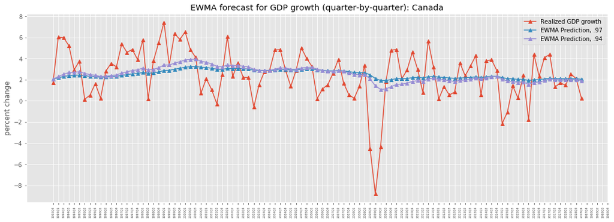

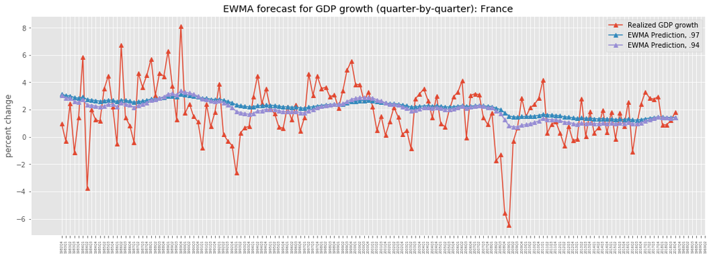

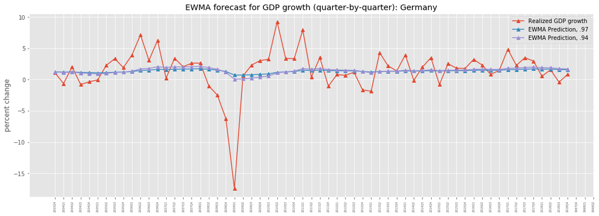

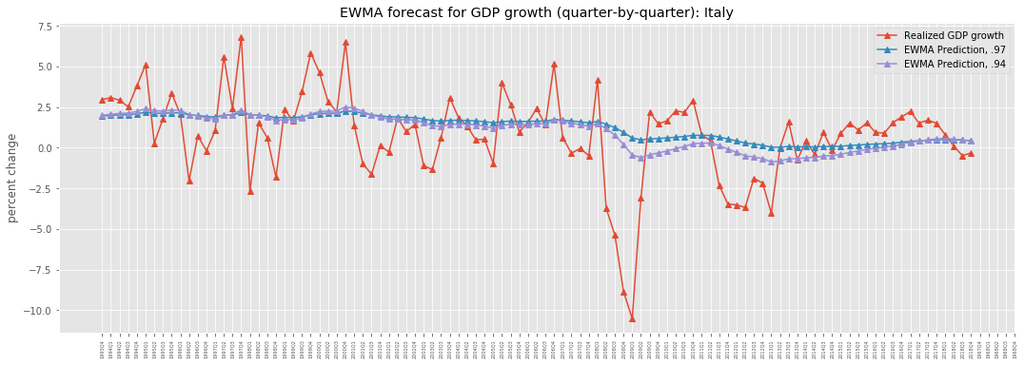

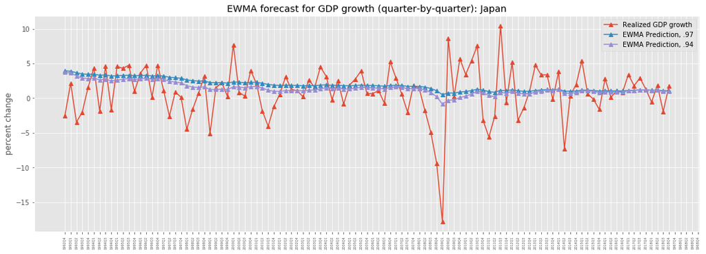

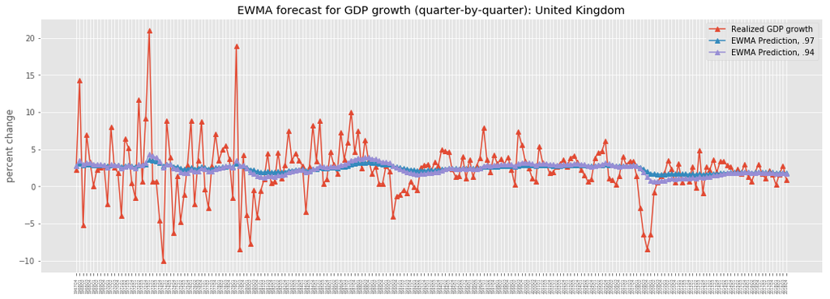

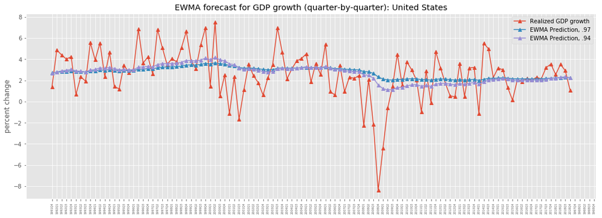

```python
for country in gdp_quarterly_q.columns:
    plt.figure(figsize=(18, 6))
    plt.plot(gdp_quarterly_q[(window_size+len_q-len_dict_q[country]):][country], marker='^', label='Realized GDP growth')
    plt.plot(forecast_ewma97_q[country], marker='^', label='EWMA Prediction, .97')
    plt.plot(forecast_ewma94_q[country], marker='^', label='EWMA Prediction, .94')
    plt.title('EWMA forecast for GDP growth (quarter-by-quarter): ' + country)
    plt.xticks(rotation=90, fontsize=5)
    plt.ylabel('percent change')
    plt.legend()
    plt.show()
```

### Error

```python
df_error_ewma97_q = gdp_quarterly_q[window_size:] - forecast_ewma97_q
df_error_ewma94_q = gdp_quarterly_q[window_size:] - forecast_ewma94_q
```

```python
mae_ewma_q = pd.DataFrame([abs(df_error_ewma97_q).mean(),abs(df_error_ewma94_q).mean()], index=['EWMA97', 'EWMA94']).T
mae_ewma_q
```

| country | EWMA97 | EWMA94 |
| --- | --- | --- |
| Canada | 1.789479 | 1.739070 |
| France | 1.538285 | 1.475739 |
| Germany | 2.139418 | 2.109226 |
| Italy | 1.841216 | 1.811537 |
| Japan | 2.726882 | 2.616274 |
| United Kingdom | 2.468933 | 2.420106 |
| United States | 1.597608 | 1.535080 |

```python
rmse_ewma_q = pd.DataFrame([np.sqrt((df_error_ewma97_q**2).mean()),np.sqrt((df_error_ewma94_q**2).mean())], index=['EWMA97', 'EWMA94']).T
rmse_ewma_q
```

| country | EWMA97 | EWMA94 |
| --- | --- | --- |
| Canada | 2.385915 | 2.287929 |
| France | 2.008992 | 1.918922 |
| Germany | 3.413809 | 3.337048 |
| Italy | 2.593909 | 2.461852 |
| Japan | 3.846453 | 3.673248 |
| United Kingdom | 3.750141 | 3.649639 |
| United States | 2.216380 | 2.114533 |

### 3.2 gdp_quarterly_y

**Method 1. Use self-defined function**

```python
forecast_ewma97_y = weighted_moving_average_forecast(gdp_quarterly_y, window_size, theta1)
forecast_ewma94_y = weighted_moving_average_forecast(gdp_quarterly_y, window_size, theta2)
```

```python
forecast_ewma97_y.head()
```

| country time | Canada | France | Germany | Italy | Japan | United Kingdom | United States |
| --- | --- | --- | --- | --- | --- | --- | --- |
| 1968Q3 | NaN | NaN | NaN | NaN | NaN | 2.869661 | NaN |
| 1968Q4 | NaN | NaN | NaN | NaN | NaN | 2.920962 | NaN |
| 1969Q1 | NaN | NaN | NaN | NaN | NaN | 2.868226 | NaN |
| 1969Q2 | NaN | NaN | NaN | NaN | NaN | 2.875716 | NaN |
| 1969Q3 | NaN | NaN | NaN | NaN | NaN | 2.850858 | NaN |

```python
forecast_ewma94_y.head()
```

| country time | Canada | France | Germany | Italy | Japan | United Kingdom | United States |
| --- | --- | --- | --- | --- | --- | --- | --- |
| 1968Q3 | NaN | NaN | NaN | NaN | NaN | 2.914542 | NaN |
| 1968Q4 | NaN | NaN | NaN | NaN | NaN | 3.014451 | NaN |
| 1969Q1 | NaN | NaN | NaN | NaN | NaN | 2.903371 | NaN |
| 1969Q2 | NaN | NaN | NaN | NaN | NaN | 2.916242 | NaN |
| 1969Q3 | NaN | NaN | NaN | NaN | NaN | 2.864095 | NaN |

**Method2. Use `df.ewm()`**

**EWMA97:**

```python
gdp_quarterly_y.ewm(min_periods=window_size, alpha=1-theta1).mean().dropna(how='all')[:-1].set_index(forecast_ewma97_y.index).head()
```

| country time | Canada | France | Germany | Italy | Japan | United Kingdom | United States |
| --- | --- | --- | --- | --- | --- | --- | --- |
| 1968Q3 | NaN | NaN | NaN | NaN | NaN | 2.925676 | NaN |
| 1968Q4 | NaN | NaN | NaN | NaN | NaN | 2.978759 | NaN |
| 1969Q1 | NaN | NaN | NaN | NaN | NaN | 3.039185 | NaN |
| 1969Q2 | NaN | NaN | NaN | NaN | NaN | 2.968918 | NaN |
| 1969Q3 | NaN | NaN | NaN | NaN | NaN | 2.974456 | NaN |

**EWMA94:**

```python
gdp_quarterly_y.ewm(min_periods=window_size, alpha=1-theta2).mean().dropna(how='all')[:-1].set_index(forecast_ewma94_y.index).head()
```

| country time | Canada | France | Germany | Italy | Japan | United Kingdom | United States |
| --- | --- | --- | --- | --- | --- | --- | --- |
| 1968Q3 | NaN | NaN | NaN | NaN | NaN | 2.926175 | NaN |
| 1968Q4 | NaN | NaN | NaN | NaN | NaN | 3.013579 | NaN |
| 1969Q1 | NaN | NaN | NaN | NaN | NaN | 3.111466 | NaN |
| 1969Q2 | NaN | NaN | NaN | NaN | NaN | 2.989991 | NaN |
| 1969Q3 | NaN | NaN | NaN | NaN | NaN | 2.997947 | NaN |

### Plot the forecast versus real data

Use the results in method1.

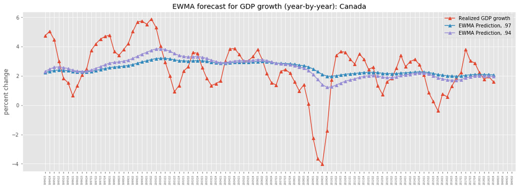

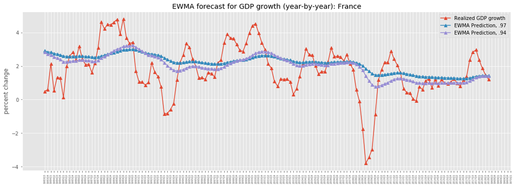

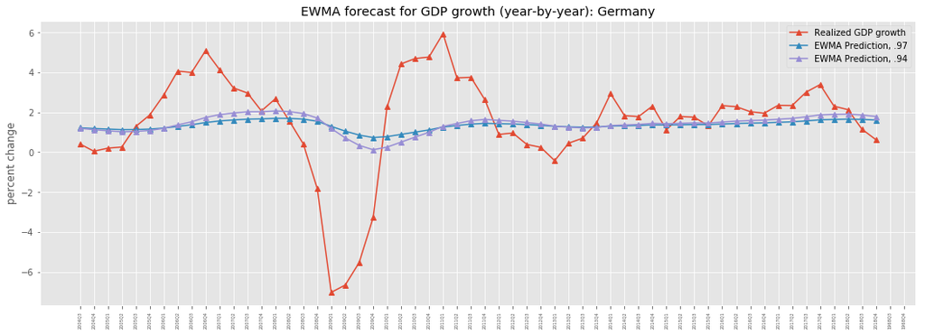

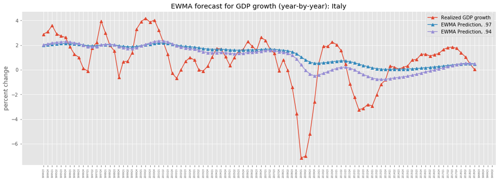

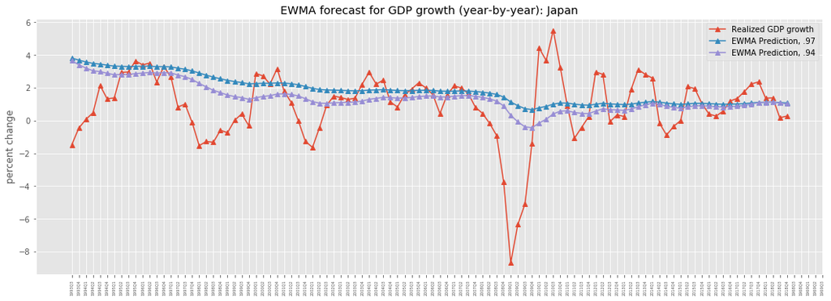

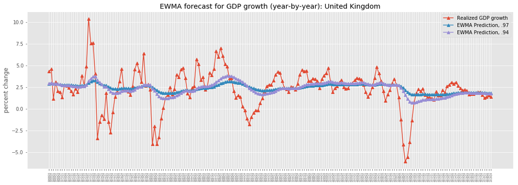

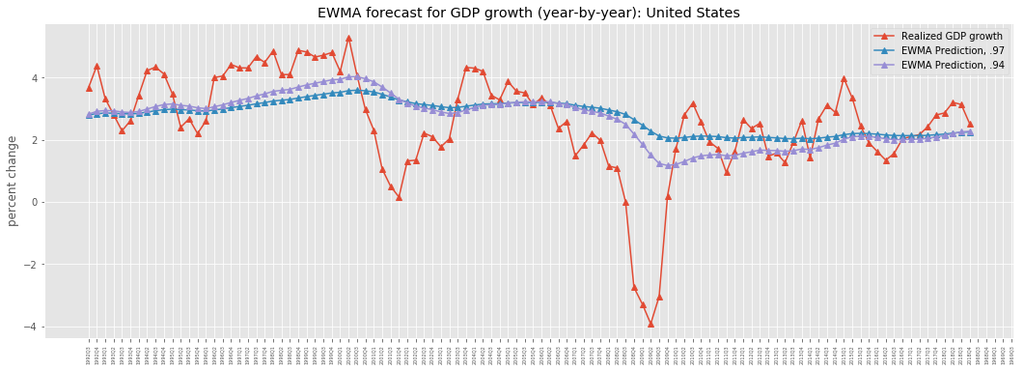

```python
for country in gdp_quarterly_y.columns:
    plt.figure(figsize=(18, 6))
    plt.plot(gdp_quarterly_y[(window_size+len_y-len_dict_y[country]):][country], marker='^', label='Realized GDP growth')
    plt.plot(forecast_ewma97_y[country], marker='^', label='EWMA Prediction, .97')
    plt.plot(forecast_ewma94_y[country], marker='^', label='EWMA Prediction, .94')
    plt.title('EWMA forecast for GDP growth (year-by-year): ' + country)
    plt.xticks(rotation=90, fontsize=5)
    plt.ylabel('percent change')
    plt.legend()
    plt.show()
```

### Error

```python
df_error_ewma97_y = gdp_quarterly_y[window_size:] - forecast_ewma97_y
df_error_ewma94_y = gdp_quarterly_y[window_size:] - forecast_ewma94_y
```

```python
mae_ewma_y = pd.DataFrame([abs(df_error_ewma97_y).mean(),abs(df_error_ewma94_y).mean()], index=['EWMA97', 'EWMA94']).T
mae_ewma_y
```

| country | EWMA97 | EWMA94 |
| --- | --- | --- |
| Canada | 1.256380 | 1.205070 |
| France | 1.057559 | 0.996640 |
| Germany | 1.681990 | 1.622429 |
| Italy | 1.365250 | 1.337388 |
| Japan | 1.613361 | 1.465606 |
| United Kingdom | 1.415172 | 1.369301 |
| United States | 1.076201 | 1.009190 |

```python
rmse_ewma_y = pd.DataFrame([np.sqrt((df_error_ewma97_y**2).mean()),np.sqrt((df_error_ewma94_y**2).mean())], index=['EWMA97', 'EWMA94']).T
rmse_ewma_y
```

| country | EWMA97 | EWMA94 |
| --- | --- | --- |
| Canada | 1.671473 | 1.563692 |
| France | 1.428804 | 1.331991 |
| Germany | 2.430308 | 2.360730 |
| Italy | 1.963703 | 1.809744 |
| Japan | 2.312455 | 2.093882 |
| United Kingdom | 2.145548 | 2.041541 |
| United States | 1.535231 | 1.412887 |

### 3.3 Error comparison

```python
mae_ewma = pd.concat([mae_ewma_q, mae_ewma_y], axis=1)
mae_ewma.columns = ['quarter-by-quarter, EWMA97', 'quarter-by-quarter, EWMA94', 'year-by-year, EWMA97', 'year-by-year, EWMA94']
mae_ewma
```

| country | quarter-by-quarter, EWMA97 | quarter-by-quarter, EWMA94 | year-by-year, EWMA97 | year-by-year, EWMA94 |
| --- | --- | --- | --- | --- |
| Canada | 1.789479 | 1.739070 | 1.256380 | 1.205070 |
| France | 1.538285 | 1.475739 | 1.057559 | 0.996640 |
| Germany | 2.139418 | 2.109226 | 1.681990 | 1.622429 |
| Italy | 1.841216 | 1.811537 | 1.365250 | 1.337388 |
| Japan | 2.726882 | 2.616274 | 1.613361 | 1.465606 |
| United Kingdom | 2.468933 | 2.420106 | 1.415172 | 1.369301 |
| United States | 1.597608 | 1.535080 | 1.076201 | 1.009190 |

```python
rmse_ewma = pd.concat([rmse_ewma_q, rmse_ewma_y], axis=1)
rmse_ewma.columns = ['quarter-by-quarter, EWMA97', 'quarter-by-quarter, EWMA94', 'year-by-year, EWMA97', 'year-by-year, EWMA94']
rmse_ewma
```

| country | quarter-by-quarter, EWMA97 | quarter-by-quarter, EWMA94 | year-by-year, EWMA97 | year-by-year, EWMA94 |
| --- | --- | --- | --- | --- |
| Canada | 2.385915 | 2.287929 | 1.671473 | 1.563692 |
| France | 2.008992 | 1.918922 | 1.428804 | 1.331991 |
| Germany | 3.413809 | 3.337048 | 2.430308 | 2.360730 |
| Italy | 2.593909 | 2.461852 | 1.963703 | 1.809744 |
| Japan | 3.846453 | 3.673248 | 2.312455 | 2.093882 |
| United Kingdom | 3.750141 | 3.649639 | 2.145548 | 2.041541 |
| United States | 2.216380 | 2.114533 | 1.535231 | 1.412887 |

P.S. Please ignore the markdown cell format error in the EWMA section. When saved in `.html`, the jupyter notebook fails to recognize multiple independent formula sign pairs: it takes \$formula1\\$ and \$formula2\\$ as a nested formula. No error with `.ipynb` format.